# Supervised Learning - Foundations Project: ReCell

## Problem Statement

### Business Context

Buying and selling used phones and tablets used to be something that happened on a handful of online marketplace sites. But the used and refurbished device market has grown considerably over the past decade, and a new IDC (International Data Corporation) forecast predicts that the used phone market would be worth \$52.7bn by 2023 with a compound annual growth rate (CAGR) of 13.6% from 2018 to 2023. This growth can be attributed to an uptick in demand for used phones and tablets that offer considerable savings compared with new models.

Refurbished and used devices continue to provide cost-effective alternatives to both consumers and businesses that are looking to save money when purchasing one. There are plenty of other benefits associated with the used device market. Used and refurbished devices can be sold with warranties and can also be insured with proof of purchase. Third-party vendors/platforms, such as Verizon, Amazon, etc., provide attractive offers to customers for refurbished devices. Maximizing the longevity of devices through second-hand trade also reduces their environmental impact and helps in recycling and reducing waste. The impact of the COVID-19 outbreak may further boost this segment as consumers cut back on discretionary spending and buy phones and tablets only for immediate needs.

### Objective

The rising potential of this comparatively under-the-radar market fuels the need for an ML-based solution to develop a dynamic pricing strategy for used and refurbished devices. ReCell, a startup aiming to tap the potential in this market, has hired you as a data scientist. They want you to analyze the data provided and build a linear regression model to predict the price of a used phone/tablet and identify factors that significantly influence it.

### Data Description

The data contains the different attributes of used/refurbished phones and tablets. The data was collected in the year 2021. The detailed data dictionary is given below.

- brand_name: Name of manufacturing brand
- os: OS on which the device runs
- screen_size: Size of the screen in cm
- 4g: Whether 4G is available or not
- 5g: Whether 5G is available or not
- main_camera_mp: Resolution of the rear camera in megapixels
- selfie_camera_mp: Resolution of the front camera in megapixels
- int_memory: Amount of internal memory (ROM) in GB
- ram: Amount of RAM in GB
- battery: Energy capacity of the device battery in mAh
- weight: Weight of the device in grams
- release_year: Year when the device model was released
- days_used: Number of days the used/refurbished device has been used
- normalized_new_price: Normalized price of a new device of the same model in euros
- normalized_used_price: Normalized price of the used/refurbished device in euros

## Importing necessary libraries

```python
# this will help in making the Python code more structured automatically (good coding practice)
%load_ext nb_black
# Libraries to help with reading and manipulating data
import numpy as np
import pandas as pd

# Libraries to help with data visualization
import matplotlib.pyplot as plt
import seaborn as sns

sns.set()

# split the data into train and test
from sklearn.model_selection import train_test_split

# to build linear regression_model
from sklearn.linear_model import LinearRegression

# to check model performance
from sklearn.metrics import mean_absolute_error, mean_squared_error, r2_score

# to build linear regression_model using statsmodels
import statsmodels.api as sm

# to compute VIF
from statsmodels.stats.outliers_influence import variance_inflation_factor
```

```
The nb_black extension is already loaded. To reload it, use:
  %reload_ext nb_black
```

## Loading the dataset

```python
# load the dataset
data = pd.read_csv("used_device_data.csv")
```

## Data Overview

### To get an overview of the data set, we will check the first few rows, get information on the number of rows and columns, check wether the data set is properly loaded, find out the data types of the respective columns and ensure that the data is stored in the preferred format and the value of each property is as expected. We will also check the statistical summary.

```python
data.head()  # to check the first few rows of the data set
```

|  | brand_name | os | screen_size | 4g | 5g | main_camera_mp | selfie_camera_mp | int_memory | ram | battery | weight | release_year | days_used | normalized_used_price | normalized_new_price |
| --- | --- | --- | --- | --- | --- | --- | --- | --- | --- | --- | --- | --- | --- | --- | --- |
| 0 | Honor | Android | 14.50 | yes | no | 13.0 | 5.0 | 64.0 | 3.0 | 3020.0 | 146.0 | 2020 | 127 | 4.307572 | 4.715100 |
| 1 | Honor | Android | 17.30 | yes | yes | 13.0 | 16.0 | 128.0 | 8.0 | 4300.0 | 213.0 | 2020 | 325 | 5.162097 | 5.519018 |
| 2 | Honor | Android | 16.69 | yes | yes | 13.0 | 8.0 | 128.0 | 8.0 | 4200.0 | 213.0 | 2020 | 162 | 5.111084 | 5.884631 |
| 3 | Honor | Android | 25.50 | yes | yes | 13.0 | 8.0 | 64.0 | 6.0 | 7250.0 | 480.0 | 2020 | 345 | 5.135387 | 5.630961 |
| 4 | Honor | Android | 15.32 | yes | no | 13.0 | 8.0 | 64.0 | 3.0 | 5000.0 | 185.0 | 2020 | 293 | 4.389995 | 4.947837 |

```python
data.shape  # to check the shape of the data set
print(f"The dataset has {data.shape[0]} rows and {data.shape[1]} columns.")
```

```
The dataset has 3454 rows and 15 columns.
```

```python
data.info()
```

```
<class 'pandas.core.frame.DataFrame'>
RangeIndex: 3454 entries, 0 to 3453
Data columns (total 15 columns):
 #   Column                 Non-Null Count  Dtype
---  ------                 --------------  -----
 0   brand_name             3454 non-null   object
 1   os                     3454 non-null   object
 2   screen_size            3454 non-null   float64
 3   4g                     3454 non-null   object
 4   5g                     3454 non-null   object
 5   main_camera_mp         3275 non-null   float64
 6   selfie_camera_mp       3452 non-null   float64
 7   int_memory             3450 non-null   float64
 8   ram                    3450 non-null   float64
 9   battery                3448 non-null   float64
 10  weight                 3447 non-null   float64
 11  release_year           3454 non-null   int64
 12  days_used              3454 non-null   int64
 13  normalized_used_price  3454 non-null   float64
 14  normalized_new_price   3454 non-null   float64
dtypes: float64(9), int64(2), object(4)
memory usage: 404.9+ KB
```

### Observations

**There are 3454 rows and 15 columns.**

**main_camera_mp, selfie_camera_mp, int_memory, ram, battery and weight columns have missing values.**

**columns brand_name, os, 4g and 5g are of object type and should be converted to categorical variables for the purpose of this exercise.**

**Dependent variable is normalized_used_price.**

```python
data.describe(include="all").T  # to get the statistical sumary of the dataset
```

|  | count | unique | top | freq | mean | std | min | 25% | 50% | 75% | max |
| --- | --- | --- | --- | --- | --- | --- | --- | --- | --- | --- | --- |
| brand_name | 3454 | 34 | Others | 502 | NaN | NaN | NaN | NaN | NaN | NaN | NaN |
| os | 3454 | 4 | Android | 3214 | NaN | NaN | NaN | NaN | NaN | NaN | NaN |
| screen_size | 3454.0 | NaN | NaN | NaN | 13.713115 | 3.80528 | 5.08 | 12.7 | 12.83 | 15.34 | 30.71 |
| 4g | 3454 | 2 | yes | 2335 | NaN | NaN | NaN | NaN | NaN | NaN | NaN |
| 5g | 3454 | 2 | no | 3302 | NaN | NaN | NaN | NaN | NaN | NaN | NaN |
| main_camera_mp | 3275.0 | NaN | NaN | NaN | 9.460208 | 4.815461 | 0.08 | 5.0 | 8.0 | 13.0 | 48.0 |
| selfie_camera_mp | 3452.0 | NaN | NaN | NaN | 6.554229 | 6.970372 | 0.0 | 2.0 | 5.0 | 8.0 | 32.0 |
| int_memory | 3450.0 | NaN | NaN | NaN | 54.573099 | 84.972371 | 0.01 | 16.0 | 32.0 | 64.0 | 1024.0 |
| ram | 3450.0 | NaN | NaN | NaN | 4.036122 | 1.365105 | 0.02 | 4.0 | 4.0 | 4.0 | 12.0 |
| battery | 3448.0 | NaN | NaN | NaN | 3133.402697 | 1299.682844 | 500.0 | 2100.0 | 3000.0 | 4000.0 | 9720.0 |
| weight | 3447.0 | NaN | NaN | NaN | 182.751871 | 88.413228 | 69.0 | 142.0 | 160.0 | 185.0 | 855.0 |
| release_year | 3454.0 | NaN | NaN | NaN | 2015.965258 | 2.298455 | 2013.0 | 2014.0 | 2015.5 | 2018.0 | 2020.0 |
| days_used | 3454.0 | NaN | NaN | NaN | 674.869716 | 248.580166 | 91.0 | 533.5 | 690.5 | 868.75 | 1094.0 |
| normalized_used_price | 3454.0 | NaN | NaN | NaN | 4.364712 | 0.588914 | 1.536867 | 4.033931 | 4.405133 | 4.7557 | 6.619433 |
| normalized_new_price | 3454.0 | NaN | NaN | NaN | 5.233107 | 0.683637 | 2.901422 | 4.790342 | 5.245892 | 5.673718 | 7.847841 |

### Observations

**The os column has 4 unique values.**

**The brand_name column has 34 unique values meaning the data is collected from 34 phone brands.**

**4g and 5g columns have 2 unique values of "yes" and "no".**

**release_year ranges from 2013 to 2020.**

**days_used ranges from 91 days to 1094 days.**

**Average normalized_used_price is 4.364 euros.**

```python
data.duplicated()  # To check for duplicates
```

```
0       False
1       False
2       False
3       False
4       False
        ...
3449    False
3450    False
3451    False
3452    False
3453    False
Length: 3454, dtype: bool
```

```python
data.duplicated().sum() #To sum for duplicate values
```

```
0
```

**There are no duplicate values in the data set**

```python
data.isnull().sum()
```

```
brand_name                 0
os                         0
screen_size                0
4g                         0
5g                         0
main_camera_mp           179
selfie_camera_mp           2
int_memory                 4
ram                        4
battery                    6
weight                     7
release_year               0
days_used                  0
normalized_used_price      0
normalized_new_price       0
dtype: int64
```

### observation

**main_camera_mp has 179 missing values**

**selfie_camera_mp has 2 missing values**

**int_memory has 4 missing values**

**ram has 4 missing values**

**battery has 6 missig values**

**weight has 7 missing values**

```python
df = data.copy()  # to create a copy of the data so that original data remains the same
```

## Exploratory Data Analysis (EDA)

- EDA is an important part of any project involving data.
- It is important to investigate and understand the data better before building a model with it.
- A few questions have been mentioned below which will help you approach the analysis in the right manner and generate insights from the data.
- A thorough analysis of the data, in addition to the questions mentioned below, should be done.

```python
def histogram_boxplot(
    data, feature, figsize=(15, 10), kde=False, bins=None
):  # function to plot a boxplot and a histogram along the same scale.

    """
    Boxplot and histogram combined

    data: dataframe
    feature: dataframe column
    figsize: size of figure (default (15,10))
    kde: whether to show the density curve (default False)
    bins: number of bins for histogram (default None)
    """
    f2, (ax_box2, ax_hist2) = plt.subplots(
        nrows=2,  # Number of rows of the subplot grid= 2
        sharex=True,  # x-axis will be shared among all subplots
        gridspec_kw={"height_ratios": (0.25, 0.75)},
        figsize=figsize,
    )  # creating the 2 subplots
    sns.boxplot(
        data=data, x=feature, ax=ax_box2, showmeans=True, color="violet"
    )  # boxplot will be created and a triangle will indicate the mean value of the column
    sns.histplot(
        data=data, x=feature, kde=kde, ax=ax_hist2, bins=bins
    ) if bins else sns.histplot(
        data=data, x=feature, kde=kde, ax=ax_hist2
    )  # For histogram
    ax_hist2.axvline(
        data[feature].mean(), color="green", linestyle="--"
    )  # Add mean to the histogram
    ax_hist2.axvline(
        data[feature].median(), color="black", linestyle="-"
    )  # Add median to the histogram
```

```python
# function to create labeled barplots


def labeled_barplot(data, feature, perc=False, n=None):
    """
    Barplot with percentage at the top

    data: dataframe
    feature: dataframe column
    perc: whether to display percentages instead of count (default is False)
    n: displays the top n category levels (default is None, i.e., display all levels)
    """

    total = len(data[feature])  # length of the column
    count = data[feature].nunique()
    if n is None:
        plt.figure(figsize=(count + 2, 18))
    else:
        plt.figure(figsize=(n + 2, 18))

    plt.xticks(rotation=90, fontsize=15)
    ax = sns.countplot(
        data=data,
        x=feature,
        palette="Paired",
        order=data[feature].value_counts().index[:n],
    )

    for p in ax.patches:
        if perc == True:
            label = "{:.1f}%".format(
                100 * p.get_height() / total
            )  # percentage of each class of the category
        else:
            label = p.get_height()  # count of each level of the category

        x = p.get_x() + p.get_width() / 2  # width of the plot
        y = p.get_height()  # height of the plot

        ax.annotate(
            label,
            (x, y),
            ha="center",
            va="center",
            size=12,
            xytext=(0, 5),
            textcoords="offset points",
        )  # annotate the percentage

    plt.show()  # show the plot
```

**Questions**:

1. What does the distribution of normalized used device prices look like?
2. What percentage of the used device market is dominated by Android devices?
3. The amount of RAM is important for the smooth functioning of a device. How does the amount of RAM vary with the brand?
4. A large battery often increases a device's weight, making it feel uncomfortable in the hands. How does the weight vary for phones and tablets offering large batteries (more than 4500 mAh)?
5. Bigger screens are desirable for entertainment purposes as they offer a better viewing experience. How many phones and tablets are available across different brands with a screen size larger than 6 inches?
6. A lot of devices nowadays offer great selfie cameras, allowing us to capture our favorite moments with loved ones. What is the distribution of devices offering greater than 8MP selfie cameras across brands?
7. Which attributes are highly correlated with the normalized price of a used device?

### Let us explore the normalized_used_price

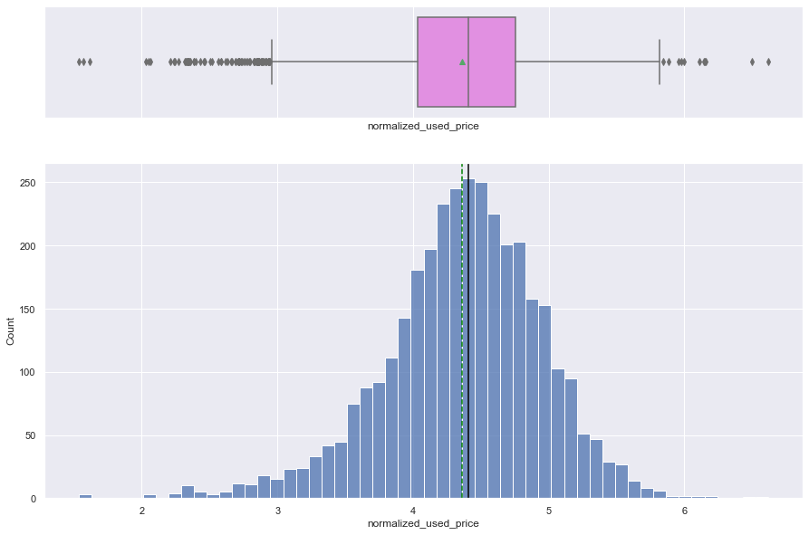

```python
histogram_boxplot(
    df, "normalized_used_price"
)  # Plot histogram and boxplot of normalized_used_price
```

## 1. What does the distribution of normalized used device prices look like?

### Observation

**The distribution follows an almost normal distribution as the mean is almost equal to the median as shown from the box plot and the statistical summary of the normalized_used_price but the outliers also makes the distribution very slightly left skewed as shown from the histogram.**.

**Outliers exist as shown from the boxplot which is indicative of the fact that some phones were very cheap compared to others while some were very expensive.**

**Mean normalized_used_price is 4.36 euros while median normalized_used_price is 4.40.**

### Let us explore the normalized_new_price

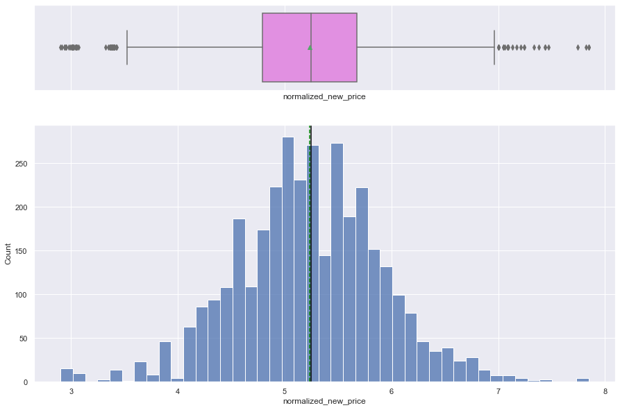

```python
histogram_boxplot(
    df, "normalized_new_price"
)  # Plot histogram and boxplot of normalized_new_price
```

### Observation

**The distribution follows an almost normal distribution as expected in the real world (NO PERFECTLY NORMAL DISTRIBUTION EXISTS) as the mean is almost equal to the median as shown from the box plot and the statistical summary of the normalized_new_price.**.

**Outliers exist as shown from the boxplot which is indicative of the fact that some phones were very cheap compared to others while some were very expensive.**

**Mean normalized_new_price is 5.23 euros while median normalized_new_price is 5.25.**

### Let us explore the screen_size

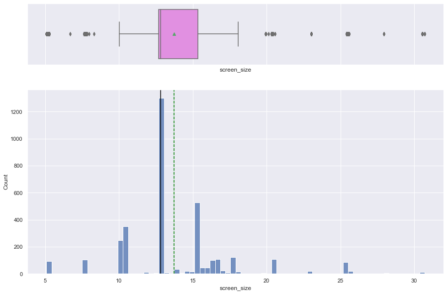

```python
histogram_boxplot(df, "screen_size")  # Plot histogram and boxplot of screen_size
```

### Observation

**Screen_size has a right skewed distribution with outliers on both sides of the boxplot**

**The mean scree_size is 13.71cm while the median screen_size is 12.83cm**

### Let us explore the main_camera_mp

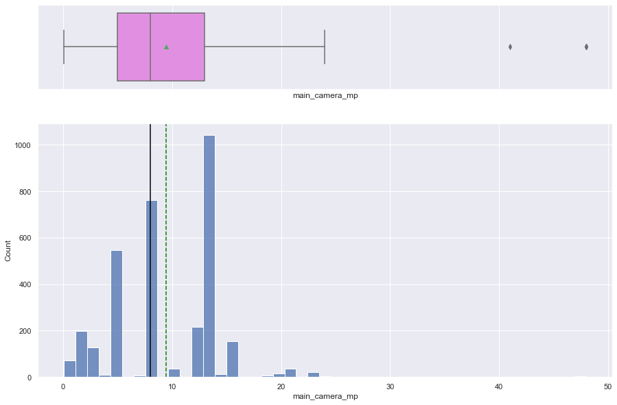

```python
histogram_boxplot(df, "main_camera_mp")  # Plot histogram and boxplot of main_camera_mp
```

### Observation

**main_camera_mp has a right skewed distribution**

**The mean resolution is 9.46mp while the median resolution is 8.0mp**

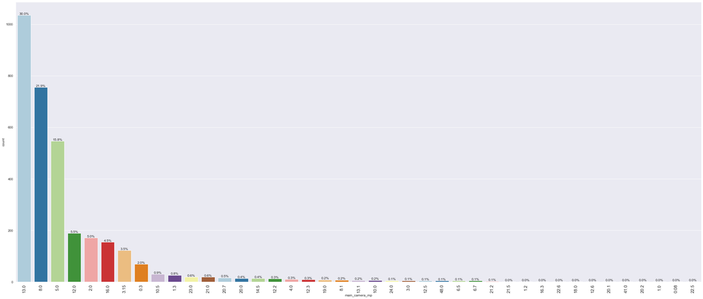

```python
labeled_barplot(df, "main_camera_mp", perc=True)
```

```python
data["main_camera_mp"].nunique()
```

```
41
```

### Observation

**There are 41 unique main_camera_mp types**

**Majority of the phones have either 13mp, 8mp or 5mp camera types**

### Let us explore the selfie_camera_mp

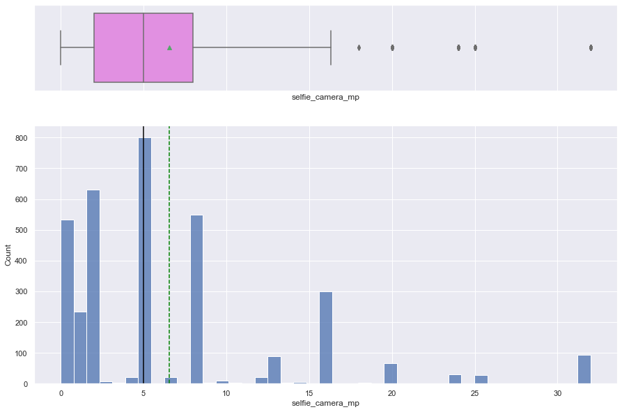

```python
histogram_boxplot(
    df, "selfie_camera_mp"
)  # Plot histogram and boxplot of selfie_camera_mp
```

### Observation

**selfie_camera_mp has a right skewed distribution**

**outliers exist to the right of the distribution which means there are phones with unusually large resolutions for the front camera**

**The mean resolution is 6.55mp while the median resolution is 5.0mp for selfie camera's**

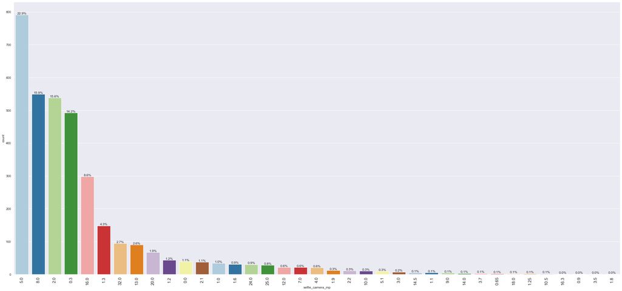

```python
labeled_barplot(df, "selfie_camera_mp", perc=True)
```

```python
data["selfie_camera_mp"].nunique()
```

```
37
```

### Observation

**There are 37 unique selfie_camera_mp types**

**22.9% of the used phones have a selfie camera of 5mp**

### Let us explore the int_memory

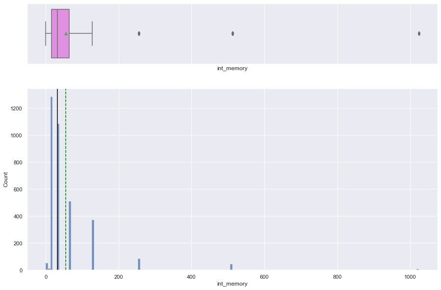

```python
histogram_boxplot(df, "int_memory")  # Plot histogram and boxplot of int_memory
```

### Observation

**int_memory has a right skewed distribution**

**outliers exist to the right of the distribution which means there are phones with very large internal memory**

**The mean internal memory is 54.57GB while the median internal memory is 32.0GB.**

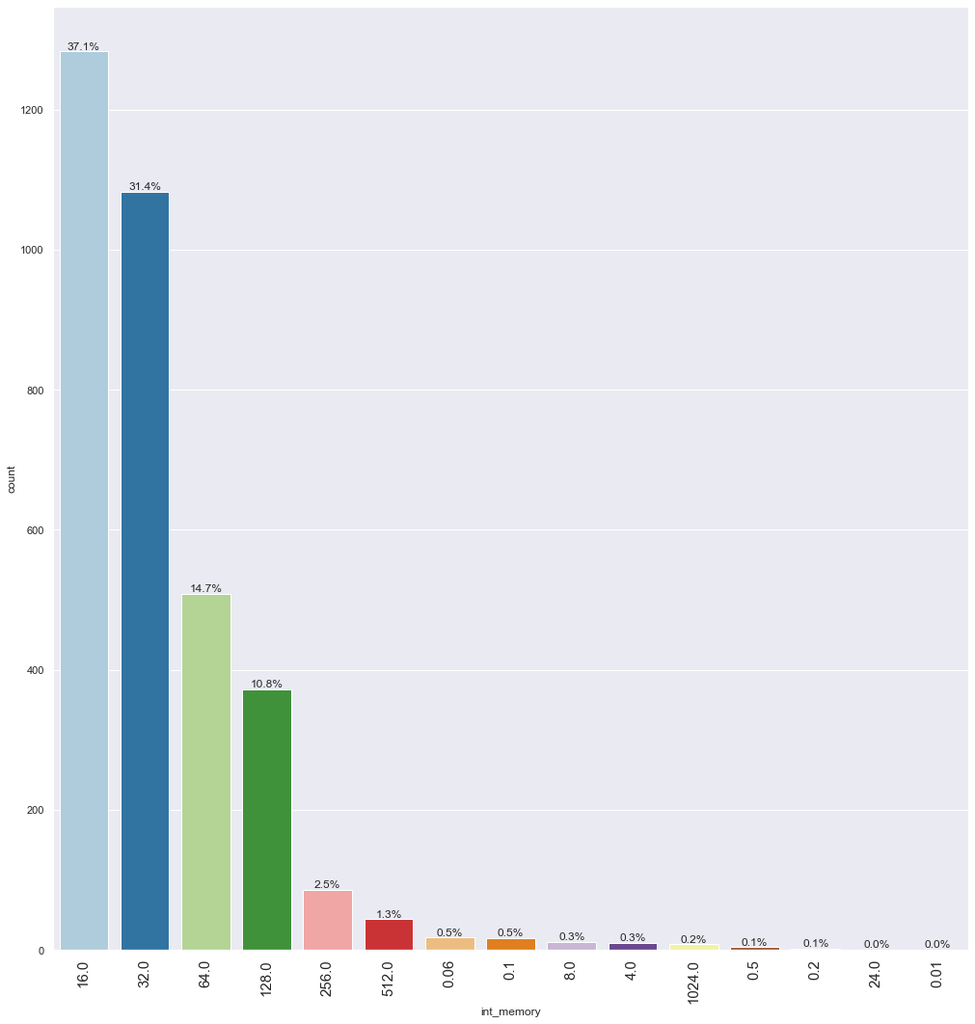

```python
labeled_barplot(df, "int_memory", perc=True)
```

```python
data["int_memory"].nunique()
```

```
15
```

### Observation

**There are 15 unique internal memory sizes**

**37.1% of phones have an internal memory of 16gb**

**0.2% of th phones have an internal memory of 1024gb.**

### Let us explore the ram

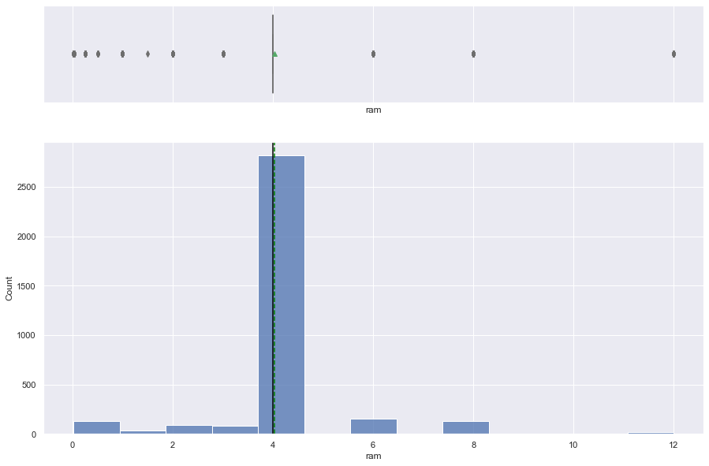

```python
histogram_boxplot(df, "ram")  # Plot histogram and boxplot of int_memory
```

### Observation

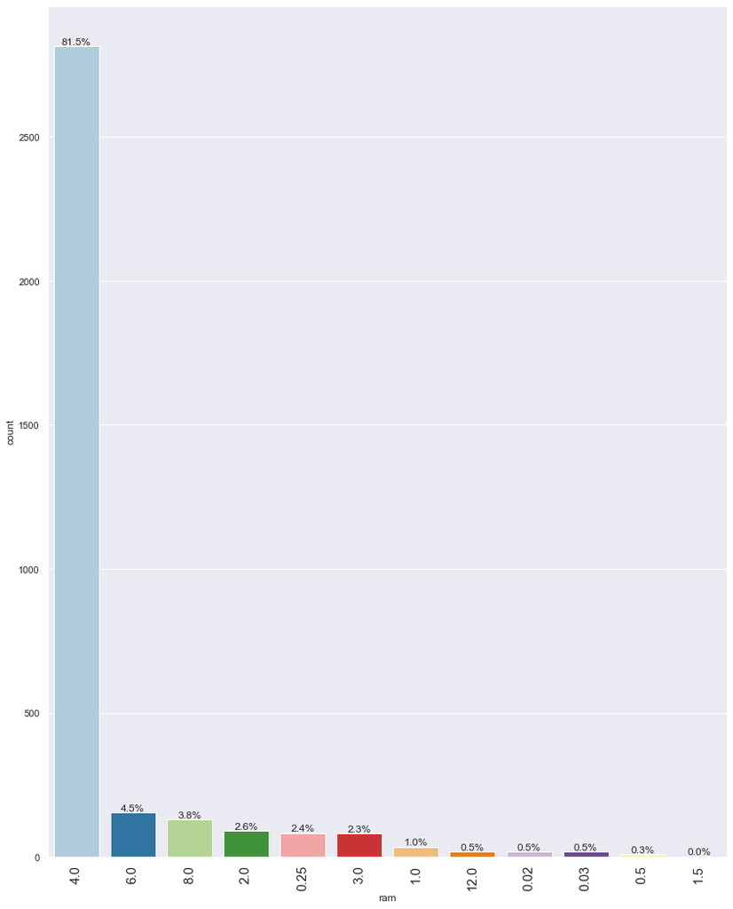

```python
labeled_barplot(df, "ram", perc=True)
```

```python
data["ram"].nunique()
```

```
12
```

### Observation

**There are 12 unique ram sizes**

**81.5% of the used phones have 4GB ram sizes**

### Let us explore the weight

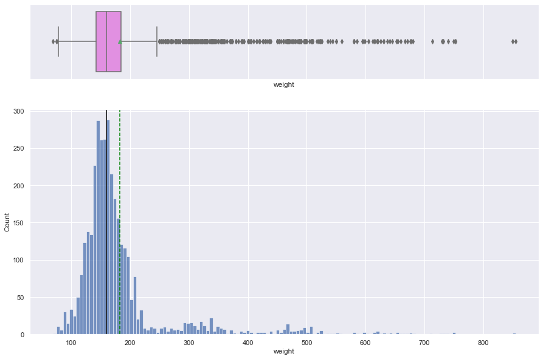

```python
histogram_boxplot(df, "weight")  # Plot histogram and boxplot of int_memory
```

### Observation

**weight has a right skewed distribution**

**A lot of outliers exist to the right of the distribution which means there are phones with very large weight and very few phones have small weight as given by the outliers to the left of the distribution**

**The mean weight is 182.75g while the median weight is 160g**

### Let us explore the battery

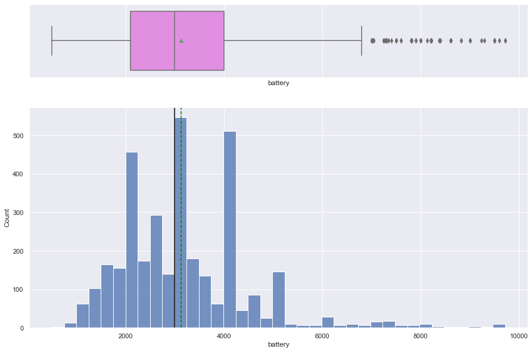

```python
histogram_boxplot(df, "battery")  # Plot histogram and boxplot of int_memory
```

### Observation

**battery has a slightly right skewed distribution and close to normal distribution**

**A lot of outliers exist to the right of the distribution which means there are batteries with a higher capacity than others**

**The mean capacity of battery is 3133mAh while the median capacity is 3000mAh**

### Let us explore the days_used

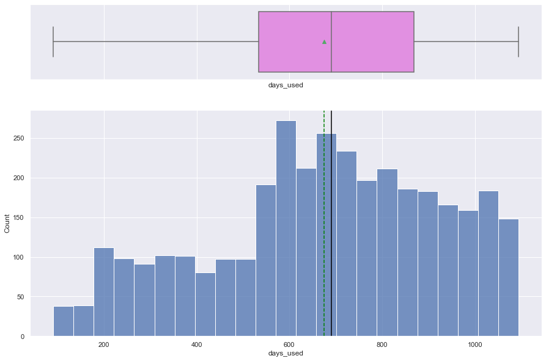

```python
histogram_boxplot(df, "days_used")  # Plot histogram and boxplot of int_memory
```

### Observation

**days_used has a left skewed or an almost normal distribution.**

**No outliers.**

**The distribution has a median of 690days and a mean around 675 days.**

### Let us explore the brand_name

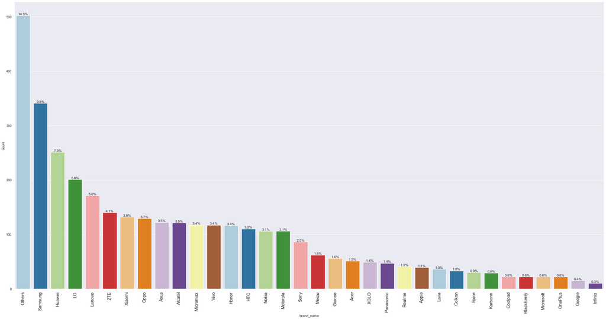

```python
labeled_barplot(df, "brand_name", perc=True)
```

### Observations

**14.5% of the phones in the dataset are of unknown brand categorized as Others**

**Samsung (9.9%) is the highest represented known brand followed by Huawei (7.3%)**

**Infinix is the least represented brand with 0.3% representation in the dataset.**

### Let us explore the os

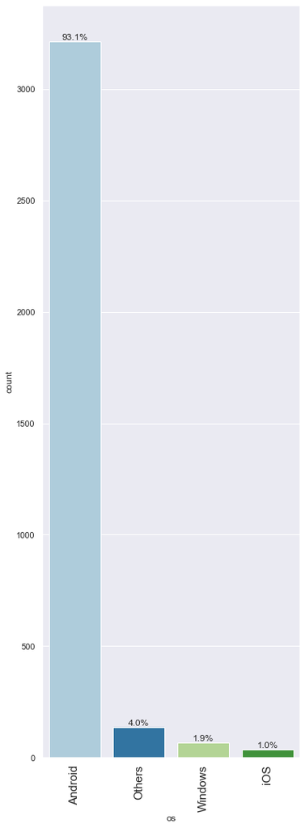

```python
labeled_barplot(df, "os", perc=True)
```

## 2. What percentage of the used device market is dominated by Android devices?

### observation

**93.1% of the used device is dominated by androif devices**

**windows and ios account for 1.9% and 1% of used device market respectively while other os accounts for 4.0% of the used device market**

### Let us explore 4g

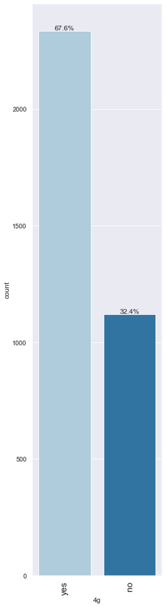

```python
labeled_barplot(df, "4g", perc=True)
```

### Observations

**67.6% of the phones have 4g while 32.4% dont have 4g**

### Let us explore 5g

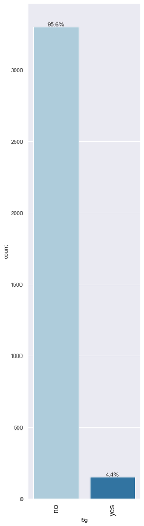

```python
labeled_barplot(df, "5g", perc=True)
```

### Observations

**4.4% of the phones have 5g while 95.6% dont have 5g which implies that majority of the used phines don't have 5g**

### Let us explore the release_year

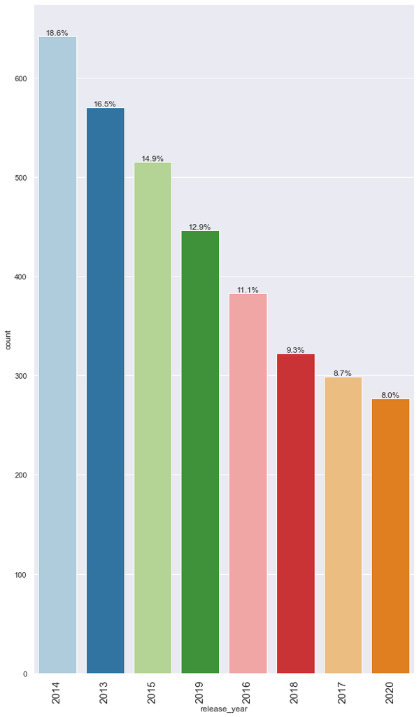

```python
labeled_barplot(df, "release_year", perc=True)
```

### Observations

**18.6% of the phones were released in 2014 which happens to be the most**

**2020 has the least amount of used phones in the market**

### 3. The amount of RAM is important for the smooth functioning of a device. How does the amount of RAM vary with the brand?

### Observation

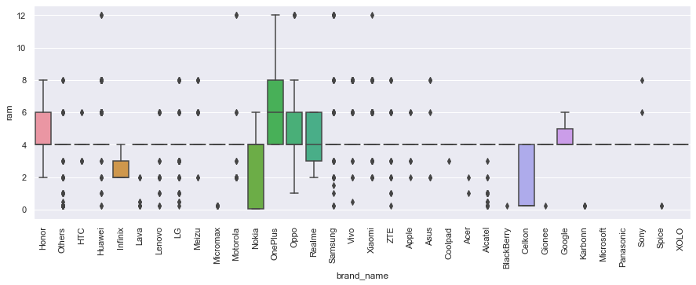

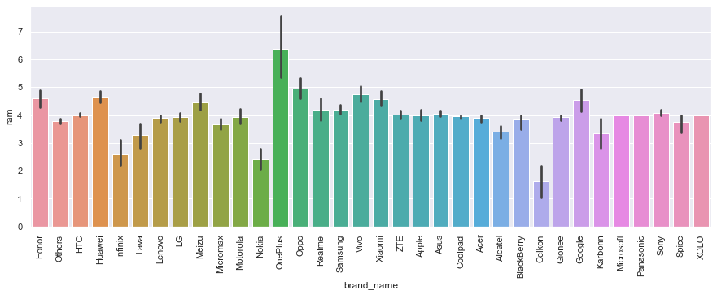

```python
plt.figure(figsize=(15, 5))
sns.boxplot(data=df, x="brand_name", y="ram")
plt.xticks(rotation=90)
plt.show()

plt.figure(figsize=(15, 5))
sns.barplot(data=df, x="brand_name", y="ram")
plt.xticks(rotation=90)
plt.show()
```

### Observation

**All brands produce phones having 4GB ram**

### 4. A large battery often increases a device's weight, making it feel uncomfortable in the hands. How does the weight vary for phones and tablets offering large batteries (more than 4500 mAh)?

```python
df_large_battery = df[df.battery > 4500]
df_large_battery.shape
```

```
(341, 15)
```

```python
df_large_battery = df[df["battery"] > 4500]
df_large_battery.groupby("brand_name")["weight"].mean()
```

```
brand_name
Acer         360.000000
Alcatel      380.000000
Apple        439.558824
Asus         313.772727
Gionee       209.430000
Google       517.000000
HTC          425.000000
Honor        248.714286
Huawei       394.486486
Infinix      193.000000
LG           366.058333
Lenovo       442.721429
Micromax     118.000000
Motorola     200.757143
Nokia        318.000000
Oppo         195.000000
Others       390.546341
Panasonic    182.000000
Realme       196.833333
Samsung      398.352000
Sony         439.500000
Spice        158.000000
Vivo         195.630769
Xiaomi       231.500000
ZTE          195.400000
Name: weight, dtype: float64
```

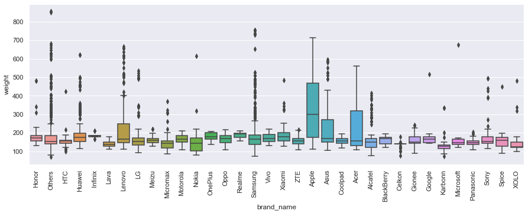

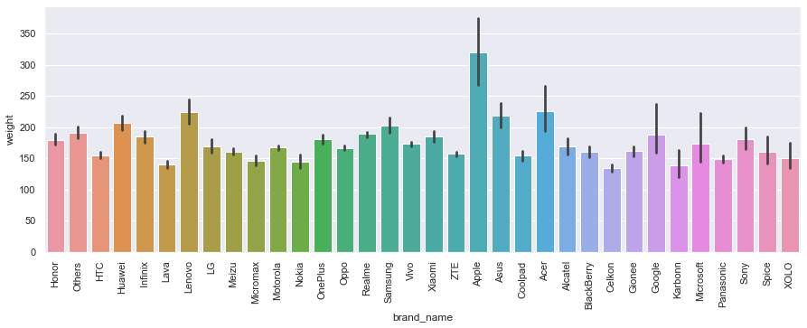

```python
plt.figure(figsize=(15, 5))
sns.boxplot(data=df, x="brand_name", y="weight")
plt.xticks(rotation=90)
plt.show()

plt.figure(figsize=(15, 5))
sns.barplot(data=df, x="brand_name", y="weight")
plt.xticks(rotation=90)
plt.show()
```

### Observation

**batteries larger than 4500mAh are not produced by all the brands as shown above**

### 5. Bigger screens are desirable for entertainment purposes as they offer a better viewing experience. How many phones and tablets are available across different brands with a screen size larger than 6 inches?

```python
df5 = data.copy()
```

```python
df_large_screen = df5[df5.screen_size > 6 * 2.54]
df_large_screen.shape
```

```
(1099, 15)
```

```python
print(
    "The total number of phones and tablets with screen size greater than 6 inches is",
    df_large_screen["brand_name"].value_counts().sum(),
)
df2 = df_large_screen["brand_name"].value_counts().reset_index()
df2.columns = ["Brand Name", "counts"]
df2
```

```
The total number of phones and tablets with screen size greater than 6 inches is 1099
```

|  | Brand Name | counts |
| --- | --- | --- |
| 0 | Huawei | 149 |
| 1 | Samsung | 119 |
| 2 | Others | 99 |
| 3 | Vivo | 80 |
| 4 | Honor | 72 |
| 5 | Oppo | 70 |
| 6 | Xiaomi | 69 |
| 7 | Lenovo | 69 |
| 8 | LG | 59 |
| 9 | Motorola | 42 |
| 10 | Asus | 41 |
| 11 | Realme | 40 |
| 12 | Alcatel | 26 |
| 13 | Apple | 24 |
| 14 | Acer | 19 |
| 15 | ZTE | 17 |
| 16 | Meizu | 17 |
| 17 | OnePlus | 16 |
| 18 | Nokia | 15 |
| 19 | Sony | 12 |
| 20 | Infinix | 10 |
| 21 | HTC | 7 |
| 22 | Micromax | 7 |
| 23 | Google | 4 |
| 24 | Coolpad | 3 |
| 25 | Gionee | 3 |
| 26 | XOLO | 3 |
| 27 | Karbonn | 2 |
| 28 | Panasonic | 2 |
| 29 | Spice | 2 |
| 30 | Microsoft | 1 |

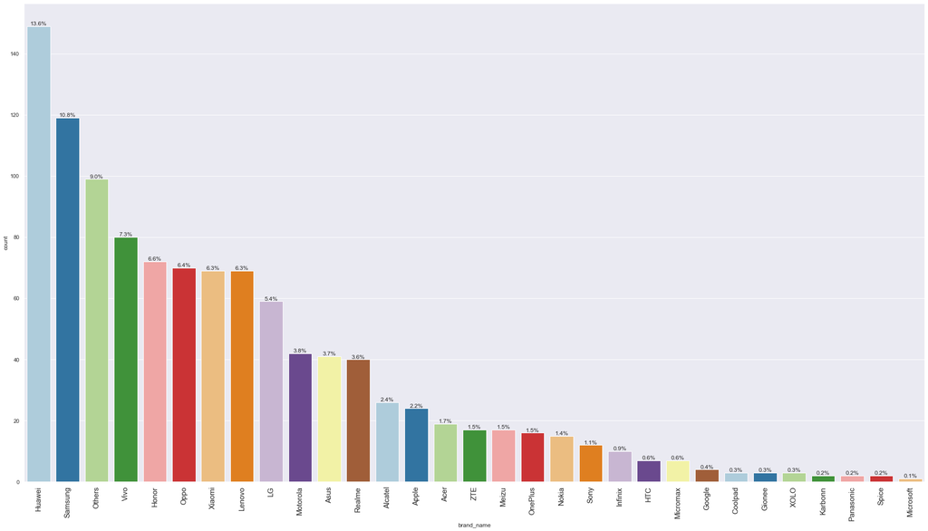

```python
labeled_barplot(df_large_screen, "brand_name", perc=True)
```

```python
df_large_screen["brand_name"].nunique()
```

```
31
```

### Observation

**celkon, Blackberry and lava have no entries for screen size larger than 6 inches**

**1099 Phones and tablets are available across brands with screen size greater than 6inches**

**Almost all brands produce a certain number of phones with screen size greater than 6inches**

```python
df_selfie_camera = df[df.selfie_camera_mp > 8]
df_selfie_camera.shape
```

```
(655, 15)
```

```python
df_main_camera = df[df.selfie_camera_mp > 8]
df_main_camera.shape
```

```
(655, 15)
```

```python
# Dataframe of devices having selfie camera mp greater than 8mp
df_selfie_camera_8mp = df[
    (df["normalized_new_price"] <= df["normalized_new_price"].median())
    & (df["selfie_camera_mp"] > 8)
]
df_selfie_camera_8mp.head()
```

|  | brand_name | os | screen_size | 4g | 5g | main_camera_mp | selfie_camera_mp | int_memory | ram | battery | weight | release_year | days_used | normalized_used_price | normalized_new_price |
| --- | --- | --- | --- | --- | --- | --- | --- | --- | --- | --- | --- | --- | --- | --- | --- |
| 17 | Honor | Android | 16.74 | yes | no | 13.0 | 16.0 | 64.0 | 4.0 | 4000.0 | 206.0 | 2019 | 421 | 4.777020 | 5.193179 |
| 22 | HTC | Android | 15.29 | yes | no | 13.0 | 16.0 | 32.0 | 3.0 | 3850.0 | 170.0 | 2019 | 187 | 4.560800 | 5.195731 |
| 62 | Infinix | Android | 15.39 | yes | no | NaN | 16.0 | 32.0 | 3.0 | 4000.0 | 178.0 | 2019 | 316 | 4.555244 | 4.602166 |
| 63 | Infinix | Android | 15.29 | yes | no | NaN | 16.0 | 32.0 | 2.0 | 4000.0 | 165.0 | 2019 | 468 | 4.416670 | 4.871297 |
| 74 | Lenovo | Android | 15.32 | yes | no | 8.0 | 16.0 | 64.0 | 4.0 | 4050.0 | 164.0 | 2019 | 482 | 4.676839 | 5.062468 |

```python
# Dataframe of devices having selfie main camera mp greater than 8mp
df_main_camera_8mp = df[
    (df["normalized_new_price"] <= df["normalized_new_price"].median())
    & (df["main_camera_mp"] > 8)
]
df_main_camera_8mp.head()
```

|  | brand_name | os | screen_size | 4g | 5g | main_camera_mp | selfie_camera_mp | int_memory | ram | battery | weight | release_year | days_used | normalized_used_price | normalized_new_price |
| --- | --- | --- | --- | --- | --- | --- | --- | --- | --- | --- | --- | --- | --- | --- | --- |
| 0 | Honor | Android | 14.50 | yes | no | 13.0 | 5.0 | 64.0 | 3.0 | 3020.0 | 146.0 | 2020 | 127 | 4.307572 | 4.715100 |
| 4 | Honor | Android | 15.32 | yes | no | 13.0 | 8.0 | 64.0 | 3.0 | 5000.0 | 185.0 | 2020 | 293 | 4.389995 | 4.947837 |
| 5 | Honor | Android | 16.23 | yes | no | 13.0 | 8.0 | 64.0 | 4.0 | 4000.0 | 176.0 | 2020 | 223 | 4.413889 | 5.060694 |
| 7 | Honor | Android | 15.77 | yes | no | 13.0 | 8.0 | 64.0 | 4.0 | 3400.0 | 164.0 | 2020 | 219 | 4.729421 | 5.188726 |
| 9 | Honor | Android | 16.23 | yes | no | 13.0 | 8.0 | 128.0 | 6.0 | 4000.0 | 176.0 | 2020 | 327 | 4.773224 | 5.073610 |

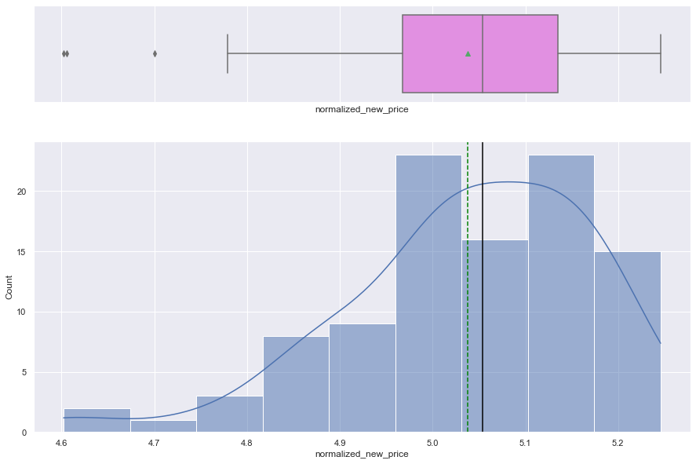

```python
histogram_boxplot(
    df_selfie_camera_8mp, "normalized_new_price", kde=True
)  # visualizing the distribution
```

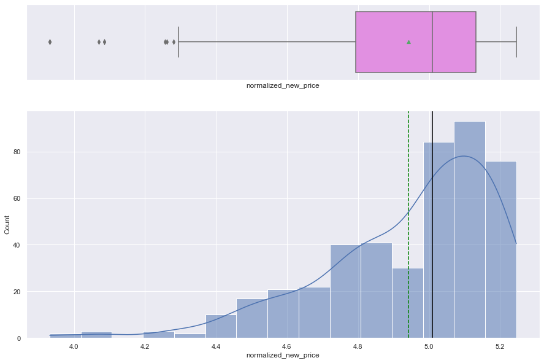

```python
histogram_boxplot(df_main_camera_8mp, "normalized_new_price", kde=True)
```

```python
# Dataframe of devices having selfie camera mp greater than 8mp
df_selfie_camera_8mp = df[
    (df["normalized_used_price"] <= df["normalized_used_price"].median())
    & (df["selfie_camera_mp"] > 8)
]
df_selfie_camera_8mp.head()
```

|  | brand_name | os | screen_size | 4g | 5g | main_camera_mp | selfie_camera_mp | int_memory | ram | battery | weight | release_year | days_used | normalized_used_price | normalized_new_price |
| --- | --- | --- | --- | --- | --- | --- | --- | --- | --- | --- | --- | --- | --- | --- | --- |
| 77 | LG | Android | 15.44 | yes | no | 5.0 | 13.0 | 64.0 | 3.0 | 4000.0 | 219.0 | 2020 | 349 | 4.350149 | 5.299467 |
| 78 | LG | Others | 5.28 | yes | no | 2.0 | 13.0 | 8.0 | 1.0 | 1470.0 | 127.0 | 2020 | 343 | 3.875566 | 5.015689 |
| 148 | Others | Android | 17.78 | yes | no | 2.0 | 16.0 | 64.0 | 4.0 | 6000.0 | 220.0 | 2020 | 135 | 4.378897 | 4.805577 |
| 297 | LG | Others | 5.28 | yes | no | 2.0 | 13.0 | 8.0 | 1.0 | 1470.0 | 127.0 | 2020 | 202 | 3.758406 | 5.021377 |
| 300 | LG | Android | 15.37 | yes | no | 5.0 | 13.0 | 32.0 | 3.0 | 4000.0 | 196.5 | 2020 | 205 | 4.232801 | 5.483219 |

```python
# Dataframe of devices having selfie main camera mp greater than 8mp
df_main_camera_8mp = df[
    (df["normalized_used_price"] <= df["normalized_used_price"].median())
    & (df["main_camera_mp"] > 8)
]
df_main_camera_8mp.head()
```

|  | brand_name | os | screen_size | 4g | 5g | main_camera_mp | selfie_camera_mp | int_memory | ram | battery | weight | release_year | days_used | normalized_used_price | normalized_new_price |
| --- | --- | --- | --- | --- | --- | --- | --- | --- | --- | --- | --- | --- | --- | --- | --- |
| 0 | Honor | Android | 14.50 | yes | no | 13.0 | 5.0 | 64.0 | 3.0 | 3020.0 | 146.0 | 2020 | 127 | 4.307572 | 4.715100 |
| 4 | Honor | Android | 15.32 | yes | no | 13.0 | 8.0 | 64.0 | 3.0 | 5000.0 | 185.0 | 2020 | 293 | 4.389995 | 4.947837 |
| 10 | Honor | Android | 15.47 | yes | no | 13.0 | 8.0 | 64.0 | 3.0 | 3020.0 | 150.0 | 2020 | 268 | 4.267037 | 4.713666 |
| 14 | Honor | Android | 14.50 | yes | no | 13.0 | 5.0 | 32.0 | 2.0 | 3020.0 | 146.0 | 2019 | 230 | 4.111366 | 4.487512 |
| 18 | Honor | Android | 14.50 | yes | no | 13.0 | 5.0 | 32.0 | 2.0 | 3020.0 | 146.0 | 2019 | 532 | 4.248638 | 4.792313 |

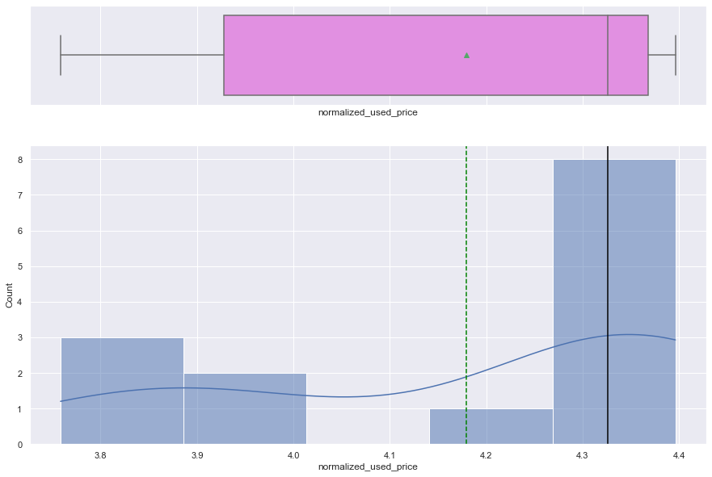

```python
histogram_boxplot(
    df_selfie_camera_8mp, "normalized_used_price", kde=True
)  # visualizing the distribution
```

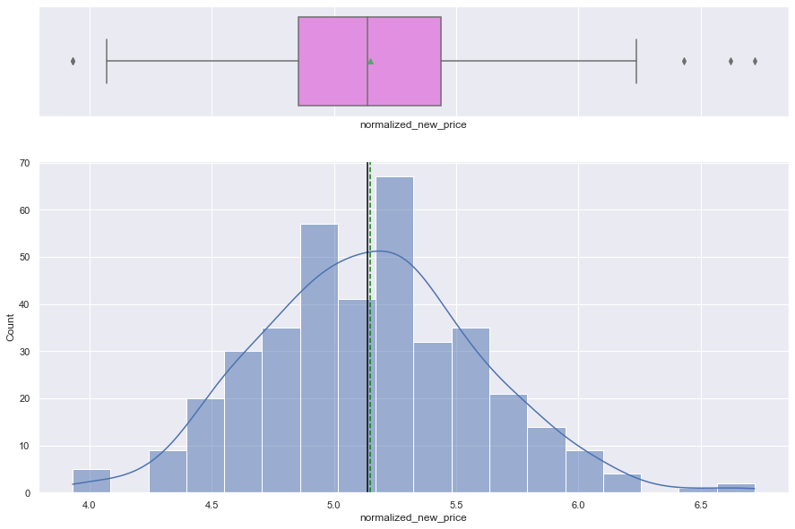

```python
histogram_boxplot(df_main_camera_8mp, "normalized_new_price", kde=True)
```

### 7. Which attributes are highly correlated with the normalized price of a used device?

### Observation

**normalized_used_price is highly correlated with normalized_new_price which means the higher the new price the higher the used price tends to increase.**

**normalized_used_price also moderately correlated with ram and selfie_camera_mp meaning the higher the phone ram or selfie camera pixels the higher the price of the used phone.**

**normalized_used_price is correlated negatively with days_used which can mean that the longer the duration the phone was used the lower the price of such used phone.**

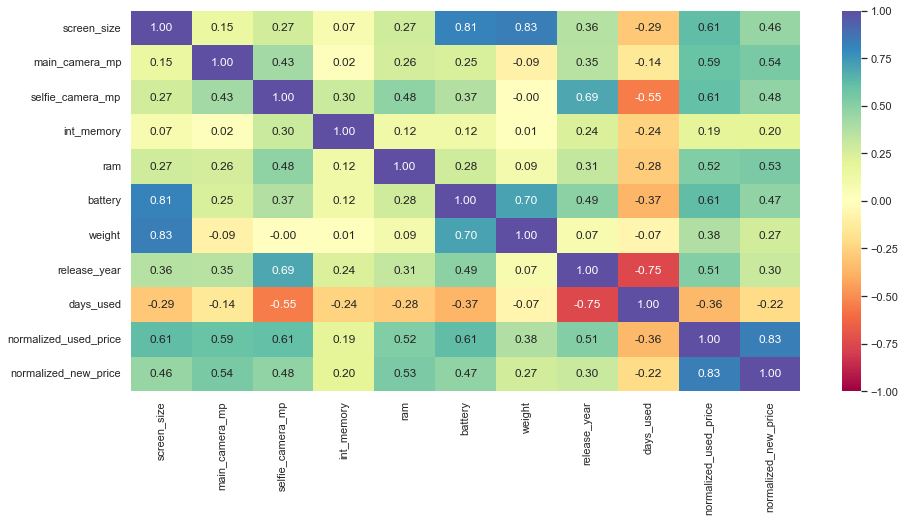

```python
cols_list = df.select_dtypes(include=np.number).columns.tolist()

plt.figure(figsize=(15, 7))
sns.heatmap(
    df[cols_list].corr(), annot=True, vmin=-1, vmax=1, fmt=".2f", cmap="Spectral"
)
plt.show()
```

### Observation

**normalized_used_price is highly correlated with normalized_new_price which means the higher the new price the higher the used price tends to increase.**

**normalized_used_price also moderately correlated with ram and selfie_camera_mp meaning the higher the phone ram or selfie camera pixels the higher the price of the used phone.**

**normalized_used_price is correlated negatively with days_used which can mean that the longer the duration the phone was used the lower the price of such used phone.**

**screen size is highly correlated with battery and weight which may imply that the higher the screen size, the larger the battery required for the phone and the heavier the phone weight will be**

### To check how the prices vary for used phones and tablets offering 4G and 5G networks.**

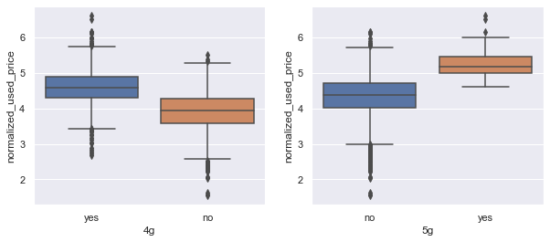

```python
plt.figure(figsize=(10, 4))

plt.subplot(121)
sns.boxplot(data=df, x="4g", y="normalized_used_price")

plt.subplot(122)
sns.boxplot(data=df, x="5g", y="normalized_used_price")

plt.show()
```

### Observation

**The median normalized used prices for tablets offering 4g and 5g are higher than those not offering 4g and 5g**

## Data Preprocessing

- Missing value treatment
- Feature engineering (if needed)
- Outlier detection and treatment (if needed)
- Preparing data for modeling
- Any other preprocessing steps (if needed)

### Missing Value Imputation

```python
df1 = df.copy()  # let's create a copy of the data
```

```python
df1.isnull().sum() #to check for missing values in the columns
```

```
brand_name                 0
os                         0
screen_size                0
4g                         0
5g                         0
main_camera_mp           179
selfie_camera_mp           2
int_memory                 4
ram                        4
battery                    6
weight                     7
release_year               0
days_used                  0
normalized_used_price      0
normalized_new_price       0
dtype: int64
```

### observation

**main_camera_mp, selfie_camera_mp, int_memory, ram, battery and weight have missing values**

```python
# To fill the missing values with the columns median
col_impute = [
    "main_camera_mp",
    "selfie_camera_mp",
    "int_memory",
    "ram",
    "battery",
    "weight",
]

df1[col_impute] = df1[col_impute].apply(lambda x: x.fillna(x.median()), axis=0)
```

```python
df1.isnull().sum()
```

```
brand_name               0
os                       0
screen_size              0
4g                       0
5g                       0
main_camera_mp           0
selfie_camera_mp         0
int_memory               0
ram                      0
battery                  0
weight                   0
release_year             0
days_used                0
normalized_used_price    0
normalized_new_price     0
dtype: int64
```

### Feature engineering

Let's create a new column years_since_release from the release_year column. We will consider the year of data collection, 2021, as the baseline. We will drop the release_year column

```python
df1["years_since_release"] = 2021 - df1["release_year"]
df1.drop("release_year", axis=1, inplace=True)
df1["years_since_release"].describe()
```

```
count    3454.000000
mean        5.034742
std         2.298455
min         1.000000
25%         3.000000
50%         5.500000
75%         7.000000
max         8.000000
Name: years_since_release, dtype: float64
```

### Outlier detection & treatment

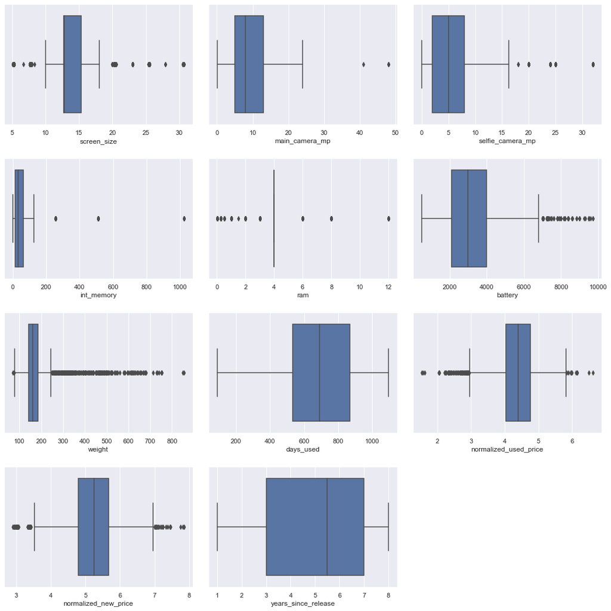

```python
# outlier detection using boxplot
num_cols = df1.select_dtypes(include=np.number).columns.tolist()

plt.figure(figsize=(15, 15))

for i, variable in enumerate(num_cols):
    plt.subplot(4, 3, i + 1)
    sns.boxplot(data=df1, x=variable)
    plt.tight_layout(pad=2)

plt.show()
```

### Observations

**There are outliers in all the numerical columns except for the newly engineered feature (years_since_release) and days_used.**

**We will not treat the outliers, treating the outliers caan lead to loss of vital information.**

## EDA

- It is a good idea to explore the data once again after manipulating it.

```python
df1.head()
```

|  | brand_name | os | screen_size | 4g | 5g | main_camera_mp | selfie_camera_mp | int_memory | ram | battery | weight | days_used | normalized_used_price | normalized_new_price | years_since_release |
| --- | --- | --- | --- | --- | --- | --- | --- | --- | --- | --- | --- | --- | --- | --- | --- |
| 0 | Honor | Android | 14.50 | yes | no | 13.0 | 5.0 | 64.0 | 3.0 | 3020.0 | 146.0 | 127 | 4.307572 | 4.715100 | 1 |
| 1 | Honor | Android | 17.30 | yes | yes | 13.0 | 16.0 | 128.0 | 8.0 | 4300.0 | 213.0 | 325 | 5.162097 | 5.519018 | 1 |
| 2 | Honor | Android | 16.69 | yes | yes | 13.0 | 8.0 | 128.0 | 8.0 | 4200.0 | 213.0 | 162 | 5.111084 | 5.884631 | 1 |
| 3 | Honor | Android | 25.50 | yes | yes | 13.0 | 8.0 | 64.0 | 6.0 | 7250.0 | 480.0 | 345 | 5.135387 | 5.630961 | 1 |
| 4 | Honor | Android | 15.32 | yes | no | 13.0 | 8.0 | 64.0 | 3.0 | 5000.0 | 185.0 | 293 | 4.389995 | 4.947837 | 1 |

```python
df1.tail()
```

|  | brand_name | os | screen_size | 4g | 5g | main_camera_mp | selfie_camera_mp | int_memory | ram | battery | weight | days_used | normalized_used_price | normalized_new_price | years_since_release |
| --- | --- | --- | --- | --- | --- | --- | --- | --- | --- | --- | --- | --- | --- | --- | --- |
| 3449 | Asus | Android | 15.34 | yes | no | 8.0 | 8.0 | 64.0 | 6.0 | 5000.0 | 190.0 | 232 | 4.492337 | 6.483872 | 2 |
| 3450 | Asus | Android | 15.24 | yes | no | 13.0 | 8.0 | 128.0 | 8.0 | 4000.0 | 200.0 | 541 | 5.037732 | 6.251538 | 3 |
| 3451 | Alcatel | Android | 15.80 | yes | no | 13.0 | 5.0 | 32.0 | 3.0 | 4000.0 | 165.0 | 201 | 4.357350 | 4.528829 | 1 |
| 3452 | Alcatel | Android | 15.80 | yes | no | 13.0 | 5.0 | 32.0 | 2.0 | 4000.0 | 160.0 | 149 | 4.349762 | 4.624188 | 1 |
| 3453 | Alcatel | Android | 12.83 | yes | no | 13.0 | 5.0 | 16.0 | 2.0 | 4000.0 | 168.0 | 176 | 4.132122 | 4.279994 | 1 |

```python
df1.info()
```

```
<class 'pandas.core.frame.DataFrame'>
RangeIndex: 3454 entries, 0 to 3453
Data columns (total 15 columns):
 #   Column                 Non-Null Count  Dtype
---  ------                 --------------  -----
 0   brand_name             3454 non-null   object
 1   os                     3454 non-null   object
 2   screen_size            3454 non-null   float64
 3   4g                     3454 non-null   object
 4   5g                     3454 non-null   object
 5   main_camera_mp         3454 non-null   float64
 6   selfie_camera_mp       3454 non-null   float64
 7   int_memory             3454 non-null   float64
 8   ram                    3454 non-null   float64
 9   battery                3454 non-null   float64
 10  weight                 3454 non-null   float64
 11  days_used              3454 non-null   int64
 12  normalized_used_price  3454 non-null   float64
 13  normalized_new_price   3454 non-null   float64
 14  years_since_release    3454 non-null   int64
dtypes: float64(9), int64(2), object(4)
memory usage: 404.9+ KB
```

```python
df1.shape
```

```
(3454, 15)
```

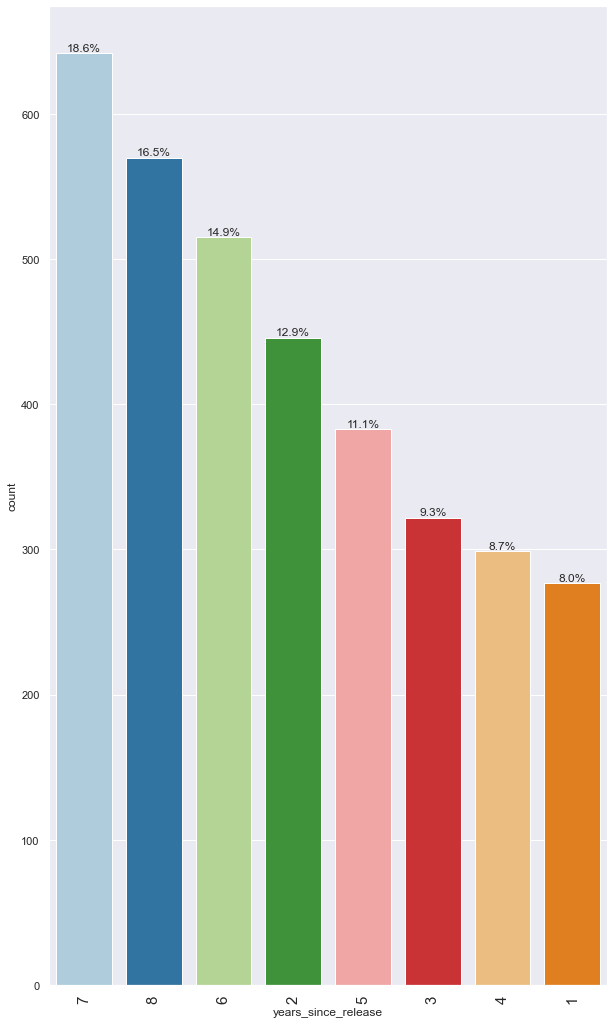

```python
labeled_barplot(df1, "years_since_release", perc=True)
```

### Observation

**Using 2021 as the base year, the years_since_release still mainatains the same basic information even after engineering a new feature**

**No null values present and we can go ahead to prepare our data for modelling**

### Data Preparation for modeling

- We want to predict the normalized price of used devices
- Before we proceed to build a model, we'll have to encode categorical features
- We'll split the data into train and test to be able to evaluate the model that we build on the train data
- We will build a Linear Regression model using the train data and then check it's performance

```python
## Complete the code to define the dependent and independent variables
X = df1.drop(["normalized_used_price"], axis=1)
y = df1["normalized_used_price"]
```

```python
X.head() #independent variables
```

|  | brand_name | os | screen_size | 4g | 5g | main_camera_mp | selfie_camera_mp | int_memory | ram | battery | weight | days_used | normalized_new_price | years_since_release |
| --- | --- | --- | --- | --- | --- | --- | --- | --- | --- | --- | --- | --- | --- | --- |
| 0 | Honor | Android | 14.50 | yes | no | 13.0 | 5.0 | 64.0 | 3.0 | 3020.0 | 146.0 | 127 | 4.715100 | 1 |
| 1 | Honor | Android | 17.30 | yes | yes | 13.0 | 16.0 | 128.0 | 8.0 | 4300.0 | 213.0 | 325 | 5.519018 | 1 |
| 2 | Honor | Android | 16.69 | yes | yes | 13.0 | 8.0 | 128.0 | 8.0 | 4200.0 | 213.0 | 162 | 5.884631 | 1 |
| 3 | Honor | Android | 25.50 | yes | yes | 13.0 | 8.0 | 64.0 | 6.0 | 7250.0 | 480.0 | 345 | 5.630961 | 1 |
| 4 | Honor | Android | 15.32 | yes | no | 13.0 | 8.0 | 64.0 | 3.0 | 5000.0 | 185.0 | 293 | 4.947837 | 1 |

```python
y.head() #dependent variable
```

```
0    4.307572
1    5.162097
2    5.111084
3    5.135387
4    4.389995
Name: normalized_used_price, dtype: float64
```

```python
# let's add the intercept to data
X = sm.add_constant(X)
```

```python
# Create dummy variables for the categorical data/independent features
X = pd.get_dummies(X, columns=["brand_name", "os", "4g", "5g"], drop_first=True)
```

```python
X.head()
```

|  | const | screen_size | main_camera_mp | selfie_camera_mp | int_memory | ram | battery | weight | days_used | normalized_new_price | ... | brand_name_Spice | brand_name_Vivo | brand_name_XOLO | brand_name_Xiaomi | brand_name_ZTE | os_Others | os_Windows | os_iOS | 4g_yes | 5g_yes |
| --- | --- | --- | --- | --- | --- | --- | --- | --- | --- | --- | --- | --- | --- | --- | --- | --- | --- | --- | --- | --- | --- |
| 0 | 1.0 | 14.50 | 13.0 | 5.0 | 64.0 | 3.0 | 3020.0 | 146.0 | 127 | 4.715100 | ... | 0 | 0 | 0 | 0 | 0 | 0 | 0 | 0 | 1 | 0 |
| 1 | 1.0 | 17.30 | 13.0 | 16.0 | 128.0 | 8.0 | 4300.0 | 213.0 | 325 | 5.519018 | ... | 0 | 0 | 0 | 0 | 0 | 0 | 0 | 0 | 1 | 1 |
| 2 | 1.0 | 16.69 | 13.0 | 8.0 | 128.0 | 8.0 | 4200.0 | 213.0 | 162 | 5.884631 | ... | 0 | 0 | 0 | 0 | 0 | 0 | 0 | 0 | 1 | 1 |
| 3 | 1.0 | 25.50 | 13.0 | 8.0 | 64.0 | 6.0 | 7250.0 | 480.0 | 345 | 5.630961 | ... | 0 | 0 | 0 | 0 | 0 | 0 | 0 | 0 | 1 | 1 |
| 4 | 1.0 | 15.32 | 13.0 | 8.0 | 64.0 | 3.0 | 5000.0 | 185.0 | 293 | 4.947837 | ... | 0 | 0 | 0 | 0 | 0 | 0 | 0 | 0 | 1 | 0 |

5 rows × 49 columns

### dummies have been created and categorical variables have been successfully encoded

```python
# splitting the data in 70:30 ratio for train to test data
X_train, X_test, y_train, y_test = train_test_split(
    X, y, test_size=0.30, random_state=1
)
```

```python
print("Number of rows in train data =", X_train.shape[0])
print("Number of rows in test data =", X_test.shape[0])
```

```
Number of rows in train data = 2417
Number of rows in test data = 1037
```

## Model Building - Linear Regression

```python
olsmodel1 = sm.OLS(y_train, X_train).fit()  ## Code to fit OLS model
```

```python
print(olsmodel1.summary())
```

```
                              OLS Regression Results
=================================================================================
Dep. Variable:     normalized_used_price   R-squared:                       0.845
Model:                               OLS   Adj. R-squared:                  0.842
Method:                    Least Squares   F-statistic:                     268.8
Date:                   Thu, 07 Jul 2022   Prob (F-statistic):               0.00
Time:                           01:38:58   Log-Likelihood:                 124.22
No. Observations:                   2417   AIC:                            -150.4
Df Residuals:                       2368   BIC:                             133.3
Df Model:                             48
Covariance Type:               nonrobust
=========================================================================================
                            coef    std err          t      P>|t|      [0.025      0.975]
-----------------------------------------------------------------------------------------
const                     1.3286      0.071     18.604      0.000       1.189       1.469
screen_size               0.0243      0.003      7.145      0.000       0.018       0.031
main_camera_mp            0.0203      0.001     13.806      0.000       0.017       0.023
selfie_camera_mp          0.0136      0.001     12.084      0.000       0.011       0.016
int_memory                0.0001   6.97e-05      1.542      0.123   -2.92e-05       0.000
ram                       0.0239      0.005      4.657      0.000       0.014       0.034
battery               -1.585e-05   7.27e-06     -2.181      0.029   -3.01e-05    -1.6e-06
weight                    0.0010      0.000      7.421      0.000       0.001       0.001
days_used              3.485e-05   3.09e-05      1.127      0.260   -2.58e-05    9.55e-05
normalized_new_price      0.4310      0.012     35.133      0.000       0.407       0.455
years_since_release      -0.0248      0.005     -5.441      0.000      -0.034      -0.016
brand_name_Alcatel        0.0153      0.048      0.321      0.748      -0.078       0.109
brand_name_Apple         -0.0116      0.147     -0.079      0.937      -0.300       0.277
brand_name_Asus           0.0195      0.048      0.408      0.683      -0.074       0.113
brand_name_BlackBerry    -0.0295      0.070     -0.420      0.675      -0.167       0.108
brand_name_Celkon        -0.0424      0.066     -0.640      0.522      -0.172       0.088
brand_name_Coolpad        0.0401      0.073      0.551      0.582      -0.103       0.183
brand_name_Gionee         0.0454      0.058      0.787      0.431      -0.068       0.159
brand_name_Google        -0.0312      0.085     -0.369      0.712      -0.197       0.135
brand_name_HTC           -0.0115      0.048     -0.240      0.811      -0.106       0.083
brand_name_Honor          0.0244      0.049      0.496      0.620      -0.072       0.121
brand_name_Huawei        -0.0081      0.044     -0.181      0.856      -0.095       0.079
brand_name_Infinix        0.1548      0.093      1.661      0.097      -0.028       0.337
brand_name_Karbonn        0.0971      0.067      1.447      0.148      -0.034       0.229
brand_name_LG            -0.0152      0.045     -0.335      0.738      -0.104       0.074
brand_name_Lava           0.0337      0.062      0.541      0.589      -0.089       0.156
```

[output cut: 19 more lines]

```
os_Windows               -0.0176      0.045     -0.389      0.697      -0.106       0.071
os_iOS                   -0.0585      0.146     -0.399      0.690      -0.346       0.229
4g_yes                    0.0507      0.016      3.190      0.001       0.020       0.082
5g_yes                   -0.0435      0.032     -1.369      0.171      -0.106       0.019
==============================================================================
Omnibus:                      217.620   Durbin-Watson:                   1.904
Prob(Omnibus):                  0.000   Jarque-Bera (JB):              409.702
Skew:                          -0.607   Prob(JB):                     1.08e-89
Kurtosis:                       4.611   Cond. No.                     1.78e+05
==============================================================================

Notes:
[1] Standard Errors assume that the covariance matrix of the errors is correctly specified.
[2] The condition number is large, 1.78e+05. This might indicate that there are
strong multicollinearity or other numerical problems.
```

### Interpreting the Regression Results:

1. **Adjusted. R-squared**: It reflects the fit of the model.
   - Adjusted R-squared values generally range from 0 to 1, where a higher value generally indicates a better fit, assuming certain conditions are met.
   - In our case, the value for adj. R-squared is **0.842**, which is good.
1. *const* coefficient: It is the Y-intercept.
   - It means that if all the predictor variable coefficients are zero, then the expected output (i.e., Y) would be equal to the *const* coefficient.
   - In our case, the value for `const` coefficient is **1.3286**
1. **Coefficient of a predictor variable**: It represents the change in the output Y due to a change in the predictor variable (everything else held constant).
   - In our case, the coefficient of `selfie_camera_mp` is **0.0136**.

## Model Performance Check

**Let's check the performance of the model using different metrics.**

- We will be using metric functions defined in sklearn for RMSE, MAE, and $R^2$.
- We will define a function to calculate MAPE and adjusted $R^2$.
- We will create a function which will print out all the above metrics in one go.

```python
# function to compute adjusted R-squared
def adj_r2_score(predictors, targets, predictions):
    r2 = r2_score(targets, predictions)
    n = predictors.shape[0]
    k = predictors.shape[1]
    return 1 - ((1 - r2) * (n - 1) / (n - k - 1))


# function to compute MAPE
def mape_score(targets, predictions):
    return np.mean(np.abs(targets - predictions) / targets) * 100


# function to compute different metrics to check performance of a regression model
def model_performance_regression(model, predictors, target):
    """
    Function to compute different metrics to check regression model performance

    model: regressor
    predictors: independent variables
    target: dependent variable
    """

    # predicting using the independent variables
    pred = model.predict(predictors)

    r2 = r2_score(target, pred)  # to compute R-squared
    adjr2 = adj_r2_score(predictors, target, pred)  # to compute adjusted R-squared
    rmse = np.sqrt(mean_squared_error(target, pred))  # to compute RMSE
    mae = mean_absolute_error(target, pred)  # to compute MAE
    mape = mape_score(target, pred)  # to compute MAPE

    # creating a dataframe of metrics
    df_perf = pd.DataFrame(
        {
            "RMSE": rmse,
            "MAE": mae,
            "R-squared": r2,
            "Adj. R-squared": adjr2,
            "MAPE": mape,
        },
        index=[0],
    )

    return df_perf
```

```python
# checking model performance on train set (seen 70% data)
print("Training Performance\n")
olsmodel1_train_perf = model_performance_regression(olsmodel1, X_train, y_train)
olsmodel1_train_perf
```

```
Training Performance
```

|  | RMSE | MAE | R-squared | Adj. R-squared | MAPE |
| --- | --- | --- | --- | --- | --- |
| 0 | 0.229849 | 0.180336 | 0.844933 | 0.841723 | 4.326958 |

```python
# checking model performance on test set (seen 30% data)
print("Test Performance\n")
olsmodel1_test_perf = model_performance_regression(
    olsmodel1, X_test, y_test
)  ## Complete the code to check the performance on test data
olsmodel1_test_perf
```

```
Test Performance
```

|  | RMSE | MAE | R-squared | Adj. R-squared | MAPE |
| --- | --- | --- | --- | --- | --- |
| 0 | 0.238306 | 0.184064 | 0.842547 | 0.834731 | 4.488006 |

### Observation

**The training R-squared is 0.845%, indicating that the model explains 84.5% of the variation in the train data. So, the model is not underfitting.**

**MAE and RMSE on the train and test sets are comparable, which shows that the model is not overfitting.**

**MAE indicates that our current model is able to predict normalized used price within a mean error of 0.18 euros on the test data.**

**MAPE on the test set suggests we can predict within 4.48% of the normalized used price.**

## Checking Linear Regression Assumptions

- In order to make statistical inferences from a linear regression model, it is important to ensure that the assumptions of linear regression are satisfied.

### 5 Assumptions would be checked

**1.No Multicollinearity**

**2.Linearity of variables**

**3.Independence of error terms**

**4.Normality of error terms**

**5.No Heteroscedasticity**

### TEST FOR MULTICOLLINEARITY

- **General Rule of thumb**:
  - If VIF is 1 then there is no correlation between the $k$th predictor and the remaining predictor variables.
  - If VIF exceeds 5 or is close to exceeding 5, we say there is moderate multicollinearity.
  - If VIF is 10 or exceeding 10, it shows signs of high multicollinearity.

```python
from statsmodels.stats.outliers_influence import variance_inflation_factor

# we will define a function to check VIF
def checking_vif(predictors):
    vif = pd.DataFrame()
    vif["feature"] = predictors.columns

    # calculating VIF for each feature
    vif["VIF"] = [
        round(variance_inflation_factor(predictors.values, i), 2)
        for i in range(len(predictors.columns))
    ]
    return vif
```

```python
checking_vif(X_train1)
```

|  | feature | VIF |
| --- | --- | --- |
| 0 | const | 228.60 |
| 1 | screen_size | 7.68 |
| 2 | main_camera_mp | 2.14 |
| 3 | selfie_camera_mp | 2.81 |
| 4 | int_memory | 1.36 |
| 5 | ram | 2.26 |
| 6 | battery | 4.07 |
| 7 | weight | 6.38 |
| 8 | days_used | 2.67 |
| 9 | normalized_new_price | 3.12 |
| 10 | years_since_release | 4.88 |
| 11 | brand_name_Alcatel | 3.41 |
| 12 | brand_name_Apple | 13.06 |
| 13 | brand_name_Asus | 3.33 |
| 14 | brand_name_BlackBerry | 1.63 |
| 15 | brand_name_Celkon | 1.77 |
| 16 | brand_name_Coolpad | 1.47 |
| 17 | brand_name_Gionee | 1.95 |
| 18 | brand_name_Google | 1.32 |
| 19 | brand_name_HTC | 3.41 |
| 20 | brand_name_Honor | 3.35 |
| 21 | brand_name_Huawei | 5.99 |
| 22 | brand_name_Infinix | 1.28 |
| 23 | brand_name_Karbonn | 1.57 |
| 24 | brand_name_LG | 4.85 |
| 25 | brand_name_Lava | 1.71 |
| 26 | brand_name_Lenovo | 4.56 |
| 27 | brand_name_Meizu | 2.17 |
| 28 | brand_name_Micromax | 3.36 |
| 29 | brand_name_Microsoft | 1.87 |
| 30 | brand_name_Motorola | 3.26 |
| 31 | brand_name_Nokia | 3.47 |
| 32 | brand_name_OnePlus | 1.44 |
| 33 | brand_name_Oppo | 3.97 |
| 34 | brand_name_Others | 9.71 |
| 35 | brand_name_Panasonic | 2.11 |
| 36 | brand_name_Realme | 1.93 |
| 37 | brand_name_Samsung | 7.54 |
| 38 | brand_name_Sony | 2.93 |
| 39 | brand_name_Spice | 1.69 |
| 40 | brand_name_Vivo | 3.65 |
| 41 | brand_name_XOLO | 2.14 |
| 42 | brand_name_Xiaomi | 3.71 |
| 43 | brand_name_ZTE | 3.80 |
| 44 | os_Others | 1.86 |
| 45 | os_Windows | 1.60 |
| 46 | os_iOS | 11.78 |
| 47 | 4g_yes | 2.48 |
| 48 | 5g_yes | 1.85 |

### Observation

**The brand_name_Apple and os_iOS have a VIF score greater than 10 which may indicate that the variables are correlated with each other and this makes logical sense as ios runs on apple devices.**

### To remove multicolinearity, we will do the following

1. Drop every column one by one that has a VIF score greater than 5.
2. Look at the adjusted R-squared and RMSE of all these models.
3. Drop the variable that makes the least change in adjusted R-squared.
4. Check the VIF scores again.
5. Continue till you get all VIF scores under 5.

Let's define a function that will help us do this.

```python
def treating_multicollinearity(predictors, target, high_vif_columns):
    """
    Checking the effect of dropping the columns showing high multicollinearity
    on model performance (adj. R-squared and RMSE)

    predictors: independent variables
    target: dependent variable
    high_vif_columns: columns having high VIF
    """
    # empty lists to store adj. R-squared and RMSE values
    adj_r2 = []
    rmse = []

    # build ols models by dropping one of the high VIF columns at a time
    # store the adjusted R-squared and RMSE in the lists defined previously
    for cols in high_vif_columns:
        # defining the new train set
        train = predictors.loc[:, ~predictors.columns.str.startswith(cols)]

        # create the model
        olsmodel = sm.OLS(target, train).fit()

        # adding adj. R-squared and RMSE to the lists
        adj_r2.append(olsmodel.rsquared_adj)
        rmse.append(np.sqrt(olsmodel.mse_resid))

    # creating a dataframe for the results
    temp = pd.DataFrame(
        {
            "col": high_vif_columns,
            "Adj. R-squared after_dropping col": adj_r2,
            "RMSE after dropping col": rmse,
        }
    ).sort_values(by="Adj. R-squared after_dropping col", ascending=False)
    temp.reset_index(drop=True, inplace=True)

    return temp
```

```python
col_list = [
    "Screen_size",
    "weight",
    "brand_name_Apple",
    "brand_name_Huawei",
    "brand_name_Others",
    "brand_name_Samsung",
    "os_iOS",
]

res = treating_multicollinearity(X_train1, y_train, col_list)
res
```

|  | col | Adj. R-squared after_dropping col | RMSE after dropping col |
| --- | --- | --- | --- |
| 0 | brand_name_Apple | 0.841856 | 0.232166 |
| 1 | brand_name_Huawei | 0.841855 | 0.232167 |
| 2 | brand_name_Others | 0.841854 | 0.232167 |
| 3 | os_iOS | 0.841846 | 0.232173 |
| 4 | brand_name_Samsung | 0.841819 | 0.232193 |
| 5 | Screen_size | 0.841790 | 0.232215 |
| 6 | weight | 0.838179 | 0.234849 |

```python
# Drop brand_name_Apple

col_to_drop = "brand_name_Apple"
X_train2 = X_train1.loc[:, ~X_train1.columns.str.startswith(col_to_drop)]
X_test2 = X_test1.loc[:, ~X_test1.columns.str.startswith(col_to_drop)]

# Check VIF now
vif = checking_vif(X_train2)
print("VIF after dropping ", col_to_drop)
vif
```

```
VIF after dropping  brand_name_Apple
```

|  | feature | VIF |
| --- | --- | --- |
| 0 | const | 228.14 |
| 1 | screen_size | 7.65 |
| 2 | main_camera_mp | 2.14 |
| 3 | selfie_camera_mp | 2.79 |
| 4 | int_memory | 1.36 |
| 5 | ram | 2.25 |
| 6 | battery | 4.07 |
| 7 | weight | 6.38 |
| 8 | days_used | 2.67 |
| 9 | normalized_new_price | 3.11 |
| 10 | years_since_release | 4.88 |
| 11 | brand_name_Alcatel | 3.23 |
| 12 | brand_name_Asus | 3.14 |
| 13 | brand_name_BlackBerry | 1.56 |
| 14 | brand_name_Celkon | 1.73 |
| 15 | brand_name_Coolpad | 1.44 |
| 16 | brand_name_Gionee | 1.89 |
| 17 | brand_name_Google | 1.29 |
| 18 | brand_name_HTC | 3.24 |
| 19 | brand_name_Honor | 3.16 |
| 20 | brand_name_Huawei | 5.58 |
| 21 | brand_name_Infinix | 1.27 |
| 22 | brand_name_Karbonn | 1.54 |
| 23 | brand_name_LG | 4.56 |
| 24 | brand_name_Lava | 1.67 |
| 25 | brand_name_Lenovo | 4.29 |
| 26 | brand_name_Meizu | 2.09 |
| 27 | brand_name_Micromax | 3.21 |
| 28 | brand_name_Microsoft | 1.84 |
| 29 | brand_name_Motorola | 3.09 |
| 30 | brand_name_Nokia | 3.26 |
| 31 | brand_name_OnePlus | 1.40 |
| 32 | brand_name_Oppo | 3.76 |
| 33 | brand_name_Others | 9.07 |
| 34 | brand_name_Panasonic | 2.03 |
| 35 | brand_name_Realme | 1.86 |
| 36 | brand_name_Samsung | 6.99 |
| 37 | brand_name_Sony | 2.79 |
| 38 | brand_name_Spice | 1.66 |
| 39 | brand_name_Vivo | 3.44 |
| 40 | brand_name_XOLO | 2.07 |
| 41 | brand_name_Xiaomi | 3.51 |
| 42 | brand_name_ZTE | 3.60 |
| 43 | os_Others | 1.74 |
| 44 | os_Windows | 1.59 |
| 45 | os_iOS | 1.91 |
| 46 | 4g_yes | 2.48 |
| 47 | 5g_yes | 1.84 |

### Observation

**Dropping brand_name_Apple has brought the VIF of os_ios below 5.**

**brand_name_Others, brand_name_Samsung, brand_name_Huawei and Screen_size and weight still have a VIF score much greater than 5.**

```python
col_list = [
    "Screen_size",
    "weight",
    "brand_name_Huawei",
    "brand_name_Others",
    "brand_name_Samsung",
]

res = treating_multicollinearity(X_train2, y_train, col_list)
res
```

|  | col | Adj. R-squared after_dropping col | RMSE after dropping col |
| --- | --- | --- | --- |
| 0 | brand_name_Huawei | 0.841921 | 0.232118 |
| 1 | brand_name_Others | 0.841921 | 0.232118 |
| 2 | brand_name_Samsung | 0.841885 | 0.232145 |
| 3 | Screen_size | 0.841856 | 0.232166 |
| 4 | weight | 0.838244 | 0.234802 |

```python
col_to_drop = "brand_name_Huawei"
X_train3 = X_train2.loc[:, ~X_train2.columns.str.startswith(col_to_drop)]
X_test3 = X_test2.loc[:, ~X_test2.columns.str.startswith(col_to_drop)]

# Check VIF now
vif = checking_vif(X_train3)
print("VIF after dropping ", col_to_drop)
vif
```

```
VIF after dropping  brand_name_Huawei
```

|  | feature | VIF |
| --- | --- | --- |
| 0 | const | 168.52 |
| 1 | screen_size | 7.63 |
| 2 | main_camera_mp | 2.13 |
| 3 | selfie_camera_mp | 2.78 |
| 4 | int_memory | 1.36 |
| 5 | ram | 2.25 |
| 6 | battery | 4.07 |
| 7 | weight | 6.38 |
| 8 | days_used | 2.67 |
| 9 | normalized_new_price | 3.10 |
| 10 | years_since_release | 4.88 |
| 11 | brand_name_Alcatel | 1.44 |
| 12 | brand_name_Asus | 1.37 |
| 13 | brand_name_BlackBerry | 1.16 |
| 14 | brand_name_Celkon | 1.26 |
| 15 | brand_name_Coolpad | 1.08 |
| 16 | brand_name_Gionee | 1.17 |
| 17 | brand_name_Google | 1.06 |
| 18 | brand_name_HTC | 1.40 |
| 19 | brand_name_Honor | 1.36 |
| 20 | brand_name_Infinix | 1.07 |
| 21 | brand_name_Karbonn | 1.14 |
| 22 | brand_name_LG | 1.61 |
| 23 | brand_name_Lava | 1.14 |
| 24 | brand_name_Lenovo | 1.56 |
| 25 | brand_name_Meizu | 1.18 |
| 26 | brand_name_Micromax | 1.48 |
| 27 | brand_name_Microsoft | 1.54 |
| 28 | brand_name_Motorola | 1.37 |
| 29 | brand_name_Nokia | 1.71 |
| 30 | brand_name_OnePlus | 1.09 |
| 31 | brand_name_Oppo | 1.47 |
| 32 | brand_name_Others | 2.44 |
| 33 | brand_name_Panasonic | 1.19 |
| 34 | brand_name_Realme | 1.19 |
| 35 | brand_name_Samsung | 2.00 |
| 36 | brand_name_Sony | 1.33 |
| 37 | brand_name_Spice | 1.16 |
| 38 | brand_name_Vivo | 1.40 |
| 39 | brand_name_XOLO | 1.24 |
| 40 | brand_name_Xiaomi | 1.40 |
| 41 | brand_name_ZTE | 1.45 |
| 42 | os_Others | 1.73 |
| 43 | os_Windows | 1.59 |
| 44 | os_iOS | 1.23 |
| 45 | 4g_yes | 2.46 |
| 46 | 5g_yes | 1.84 |

### Observation

**Dropping brand_name_Huawei has brought the VIF of other variables below 5. except screen size and weight**

```python
col_list = ["Screen_size", "weight"]
res = treating_multicollinearity(X_train2, y_train, col_list)
res
```

|  | col | Adj. R-squared after_dropping col | RMSE after dropping col |
| --- | --- | --- | --- |
| 0 | Screen_size | 0.841856 | 0.232166 |
| 1 | weight | 0.838244 | 0.234802 |

```python
olsmodel3 = sm.OLS(y_train, X_train).fit()  ## Code to fit OLS model
```

```python
print(olsmodel3.summary())
```

```
                              OLS Regression Results
=================================================================================
Dep. Variable:     normalized_used_price   R-squared:                       0.845
Model:                               OLS   Adj. R-squared:                  0.842
Method:                    Least Squares   F-statistic:                     268.8
Date:                   Thu, 07 Jul 2022   Prob (F-statistic):               0.00
Time:                           03:25:00   Log-Likelihood:                 124.22
No. Observations:                   2417   AIC:                            -150.4
Df Residuals:                       2368   BIC:                             133.3
Df Model:                             48
Covariance Type:               nonrobust
=========================================================================================
                            coef    std err          t      P>|t|      [0.025      0.975]
-----------------------------------------------------------------------------------------
const                     1.3286      0.071     18.604      0.000       1.189       1.469
screen_size               0.0243      0.003      7.145      0.000       0.018       0.031
main_camera_mp            0.0203      0.001     13.806      0.000       0.017       0.023
selfie_camera_mp          0.0136      0.001     12.084      0.000       0.011       0.016
int_memory                0.0001   6.97e-05      1.542      0.123   -2.92e-05       0.000
ram                       0.0239      0.005      4.657      0.000       0.014       0.034
battery               -1.585e-05   7.27e-06     -2.181      0.029   -3.01e-05    -1.6e-06
weight                    0.0010      0.000      7.421      0.000       0.001       0.001
days_used              3.485e-05   3.09e-05      1.127      0.260   -2.58e-05    9.55e-05
normalized_new_price      0.4310      0.012     35.133      0.000       0.407       0.455
years_since_release      -0.0248      0.005     -5.441      0.000      -0.034      -0.016
brand_name_Alcatel        0.0153      0.048      0.321      0.748      -0.078       0.109
brand_name_Apple         -0.0116      0.147     -0.079      0.937      -0.300       0.277
brand_name_Asus           0.0195      0.048      0.408      0.683      -0.074       0.113
brand_name_BlackBerry    -0.0295      0.070     -0.420      0.675      -0.167       0.108
brand_name_Celkon        -0.0424      0.066     -0.640      0.522      -0.172       0.088
brand_name_Coolpad        0.0401      0.073      0.551      0.582      -0.103       0.183
brand_name_Gionee         0.0454      0.058      0.787      0.431      -0.068       0.159
brand_name_Google        -0.0312      0.085     -0.369      0.712      -0.197       0.135
brand_name_HTC           -0.0115      0.048     -0.240      0.811      -0.106       0.083
brand_name_Honor          0.0244      0.049      0.496      0.620      -0.072       0.121
brand_name_Huawei        -0.0081      0.044     -0.181      0.856      -0.095       0.079
brand_name_Infinix        0.1548      0.093      1.661      0.097      -0.028       0.337
brand_name_Karbonn        0.0971      0.067      1.447      0.148      -0.034       0.229
brand_name_LG            -0.0152      0.045     -0.335      0.738      -0.104       0.074
brand_name_Lava           0.0337      0.062      0.541      0.589      -0.089       0.156
```

[output cut: 19 more lines]

```
os_Windows               -0.0176      0.045     -0.389      0.697      -0.106       0.071
os_iOS                   -0.0585      0.146     -0.399      0.690      -0.346       0.229
4g_yes                    0.0507      0.016      3.190      0.001       0.020       0.082
5g_yes                   -0.0435      0.032     -1.369      0.171      -0.106       0.019
==============================================================================
Omnibus:                      217.620   Durbin-Watson:                   1.904
Prob(Omnibus):                  0.000   Jarque-Bera (JB):              409.702
Skew:                          -0.607   Prob(JB):                     1.08e-89
Kurtosis:                       4.611   Cond. No.                     1.78e+05
==============================================================================

Notes:
[1] Standard Errors assume that the covariance matrix of the errors is correctly specified.
[2] The condition number is large, 1.78e+05. This might indicate that there are
strong multicollinearity or other numerical problems.
```

### Observations

**we wont drop all the variables at once as p-value changes after dropping variables.**

**Build a model, check the p-values of the variables, and drop the column with the highest p-value.**

**Create a new model without the dropped feature, check the p-values of the variables, and drop the column with the highest p-value.**

**Repeat the above two steps till there are no columns with p-value > 0.05.**

**The above process can also be done manually by picking one variable at a time that has a high p-value, dropping it, and building a model again. But that might be a little tedious and using a loop will be more efficient.**

## DROPPING P-VALUES > 0.05

```python
# initial list of columns
cols = X_train3.columns.tolist()

# setting an initial max p-value
max_p_value = 1

# Loop to check for p-values of the variables and drop the column with the highest p-value.
while len(cols) > 0:
    # defining the train set
    X_train_aux = X_train3[cols]

    # fitting the model
    model = sm.OLS(y_train, X_train_aux).fit()

    # getting the p-values and the maximum p-value
    p_values = model.pvalues
    max_p_value = max(p_values)

    # name of the variable with maximum p-value
    feature_with_p_max = p_values.idxmax()

    if max_p_value > 0.05:
        cols.remove(feature_with_p_max)
    else:
        break

selected_features = cols  # variables with p-values lesser than 0.05
print(selected_features)
```

```
['const', 'screen_size', 'main_camera_mp', 'selfie_camera_mp', 'ram', 'battery', 'weight', 'normalized_new_price', 'years_since_release', 'brand_name_Lenovo', 'brand_name_Nokia', 'brand_name_Realme', 'brand_name_Xiaomi', 'os_Others', '4g_yes']
```

```python
X_train4 = X_train3[selected_features]
X_test4 = X_test3[selected_features]
```

```python
olsmodel2 = sm.OLS(
    y_train, X_train4
).fit()  ## Complete the code fit OLS() on updated dataset (no multicollinearity and no insignificant predictors)
print(olsmodel2.summary())
```

```
                              OLS Regression Results
=================================================================================
Dep. Variable:     normalized_used_price   R-squared:                       0.843
Model:                               OLS   Adj. R-squared:                  0.842
Method:                    Least Squares   F-statistic:                     918.5
Date:                   Thu, 07 Jul 2022   Prob (F-statistic):               0.00
Time:                           03:40:01   Log-Likelihood:                 106.20
No. Observations:                   2417   AIC:                            -182.4
Df Residuals:                       2402   BIC:                            -95.55
Df Model:                             14
Covariance Type:               nonrobust
========================================================================================
                           coef    std err          t      P>|t|      [0.025      0.975]
----------------------------------------------------------------------------------------
const                    1.3803      0.052     26.693      0.000       1.279       1.482
screen_size              0.0254      0.003      7.683      0.000       0.019       0.032
main_camera_mp           0.0207      0.001     15.298      0.000       0.018       0.023
selfie_camera_mp         0.0141      0.001     13.367      0.000       0.012       0.016
ram                      0.0210      0.004      4.733      0.000       0.012       0.030
battery              -1.459e-05   7.12e-06     -2.051      0.040   -2.85e-05   -6.37e-07
weight                   0.0009      0.000      7.148      0.000       0.001       0.001
normalized_new_price     0.4233      0.011     39.188      0.000       0.402       0.445
years_since_release     -0.0222      0.004     -6.075      0.000      -0.029      -0.015
brand_name_Lenovo        0.0477      0.021      2.220      0.027       0.006       0.090
brand_name_Nokia         0.0652      0.031      2.132      0.033       0.005       0.125
brand_name_Realme        0.1067      0.045      2.351      0.019       0.018       0.196
brand_name_Xiaomi        0.0988      0.026      3.871      0.000       0.049       0.149
os_Others               -0.0671      0.030     -2.246      0.025      -0.126      -0.009
4g_yes                   0.0469      0.015      3.139      0.002       0.018       0.076
==============================================================================
Omnibus:                      228.912   Durbin-Watson:                   1.907
Prob(Omnibus):                  0.000   Jarque-Bera (JB):              453.321
Skew:                          -0.617   Prob(JB):                     3.65e-99
Kurtosis:                       4.726   Cond. No.                     3.94e+04
==============================================================================

Notes:
[1] Standard Errors assume that the covariance matrix of the errors is correctly specified.
[2] The condition number is large, 3.94e+04. This might indicate that there are
strong multicollinearity or other numerical problems.
```

**Now no feature has p-value greater than 0.05, so we'll consider the features in X_train4 as the final ones and olsmodel2 as final model.**

### Observations

**Adjusted R-squared is still 0.842, i.e., our model is able to explain 84.2% of the variance. This shows that the model is very good.**

**The adjusted R-squared in olsmodel1 (where we considered all the variables) was 0.842, This shows that the variables we dropped were not affecting the model much.**